# Miniproject in Introduction to Data Science ITVEST Data Science and Big Data (DSBD)

```r
if(!require("corrplot"))
  install.packages("corrplot")
library(tidyverse)
library(lubridate)
library(pander) # for prettier tables
library(scales) # for making prettier axes in plots
library(stringr)
library(factoextra)
library(corrplot)
library(nycflights13)
theme_set(theme_bw())

panderOptions('big.mark', ',')
```

# 1 Formalia

Deadline for hand-in: Jan 3, 2018 at 23:55.

Where: Moodle.

What: Rmd file. Possibly also pdf (or html), but Rmd is mandatory.

Groups: Maximum 3 participants, however the project must be handed in individually.

# 2 Exercises

Here, we focus on the `airlines`, `airports`, `flights`, `planes`, and `weather` datasets:

```r
library(nycflights13)

airlines
```

```
## # A tibble: 16 x 2
##    carrier                        name
##      <chr>                       <chr>
##  1      9E           Endeavor Air Inc.
##  2      AA      American Airlines Inc.
##  3      AS        Alaska Airlines Inc.
##  4      B6             JetBlue Airways
##  5      DL        Delta Air Lines Inc.
##  6      EV    ExpressJet Airlines Inc.
##  7      F9      Frontier Airlines Inc.
##  8      FL AirTran Airways Corporation
##  9      HA      Hawaiian Airlines Inc.
## 10      MQ                   Envoy Air
## 11      OO       SkyWest Airlines Inc.
## 12      UA       United Air Lines Inc.
## 13      US             US Airways Inc.
## 14      VX              Virgin America
## 15      WN      Southwest Airlines Co.
## 16      YV          Mesa Airlines Inc.
```

```r
airports
```

```
## # A tibble: 1,458 x 8
##      faa                           name      lat        lon   alt    tz
##    <chr>                          <chr>    <dbl>      <dbl> <int> <dbl>
##  1   04G              Lansdowne Airport 41.13047  -80.61958  1044    -5
##  2   06A  Moton Field Municipal Airport 32.46057  -85.68003   264    -6
##  3   06C            Schaumburg Regional 41.98934  -88.10124   801    -6
##  4   06N                Randall Airport 41.43191  -74.39156   523    -5
##  5   09J          Jekyll Island Airport 31.07447  -81.42778    11    -5
##  6   0A9 Elizabethton Municipal Airport 36.37122  -82.17342  1593    -5
##  7   0G6        Williams County Airport 41.46731  -84.50678   730    -5
##  8   0G7  Finger Lakes Regional Airport 42.88356  -76.78123   492    -5
##  9   0P2   Shoestring Aviation Airfield 39.79482  -76.64719  1000    -5
## 10   0S9          Jefferson County Intl 48.05381 -122.81064   108    -8
## # ... with 1,448 more rows, and 2 more variables: dst <chr>, tzone <chr>
```

```r
flights
```

```
## # A tibble: 336,776 x 19
##     year month   day dep_time sched_dep_time dep_delay arr_time
##    <int> <int> <int>    <int>          <int>     <dbl>    <int>
##  1  2013     1     1      517            515         2      830
##  2  2013     1     1      533            529         4      850
##  3  2013     1     1      542            540         2      923
##  4  2013     1     1      544            545        -1     1004
##  5  2013     1     1      554            600        -6      812
##  6  2013     1     1      554            558        -4      740
##  7  2013     1     1      555            600        -5      913
##  8  2013     1     1      557            600        -3      709
##  9  2013     1     1      557            600        -3      838
## 10  2013     1     1      558            600        -2      753
## # ... with 336,766 more rows, and 12 more variables: sched_arr_time <int>,
## #   arr_delay <dbl>, carrier <chr>, flight <int>, tailnum <chr>,
## #   origin <chr>, dest <chr>, air_time <dbl>, distance <dbl>, hour <dbl>,
## #   minute <dbl>, time_hour <dttm>
```

```r
planes
```

```
## # A tibble: 3,322 x 9
##    tailnum  year                    type     manufacturer     model
##      <chr> <int>                   <chr>            <chr>     <chr>
##  1  N10156  2004 Fixed wing multi engine          EMBRAER EMB-145XR
##  2  N102UW  1998 Fixed wing multi engine AIRBUS INDUSTRIE  A320-214
##  3  N103US  1999 Fixed wing multi engine AIRBUS INDUSTRIE  A320-214
##  4  N104UW  1999 Fixed wing multi engine AIRBUS INDUSTRIE  A320-214
##  5  N10575  2002 Fixed wing multi engine          EMBRAER EMB-145LR
##  6  N105UW  1999 Fixed wing multi engine AIRBUS INDUSTRIE  A320-214
##  7  N107US  1999 Fixed wing multi engine AIRBUS INDUSTRIE  A320-214
##  8  N108UW  1999 Fixed wing multi engine AIRBUS INDUSTRIE  A320-214
##  9  N109UW  1999 Fixed wing multi engine AIRBUS INDUSTRIE  A320-214
## 10  N110UW  1999 Fixed wing multi engine AIRBUS INDUSTRIE  A320-214
## # ... with 3,312 more rows, and 4 more variables: engines <int>,
## #   seats <int>, speed <int>, engine <chr>
```

```r
weather
```

```
## # A tibble: 26,130 x 15
##    origin  year month   day  hour  temp  dewp humid wind_dir wind_speed
##     <chr> <dbl> <dbl> <int> <int> <dbl> <dbl> <dbl>    <dbl>      <dbl>
##  1    EWR  2013     1     1     0 37.04 21.92 53.97      230   10.35702
##  2    EWR  2013     1     1     1 37.04 21.92 53.97      230   13.80936
##  3    EWR  2013     1     1     2 37.94 21.92 52.09      230   12.65858
##  4    EWR  2013     1     1     3 37.94 23.00 54.51      230   13.80936
##  5    EWR  2013     1     1     4 37.94 24.08 57.04      240   14.96014
##  6    EWR  2013     1     1     6 39.02 26.06 59.37      270   10.35702
##  7    EWR  2013     1     1     7 39.02 26.96 61.63      250    8.05546
##  8    EWR  2013     1     1     8 39.02 28.04 64.43      240   11.50780
##  9    EWR  2013     1     1     9 39.92 28.04 62.21      250   12.65858
## 10    EWR  2013     1     1    10 39.02 28.04 64.43      260   12.65858
## # ... with 26,120 more rows, and 5 more variables: wind_gust <dbl>,
## #   precip <dbl>, pressure <dbl>, visib <dbl>, time_hour <dttm>
```

Remember to read about the datasets.

# 3 Exercises

## 3.1 Exercise

Construct a barplot displaying number of flights per month.

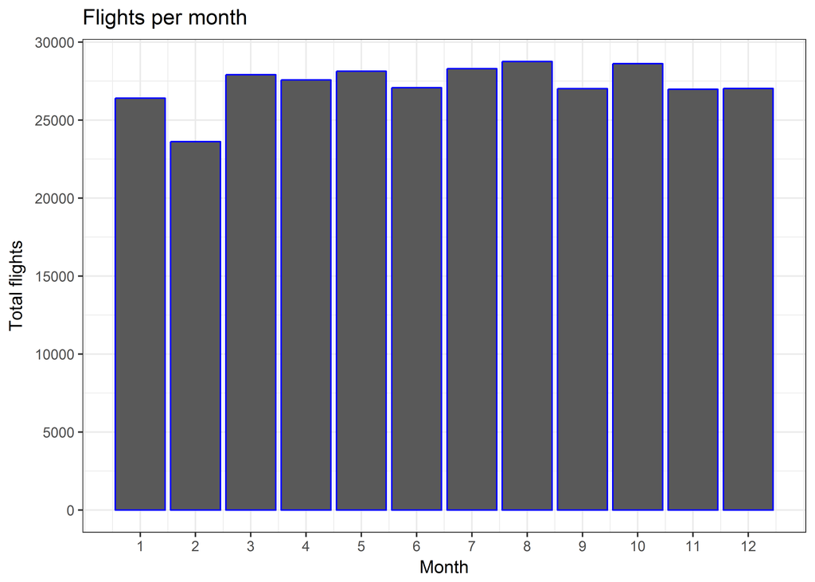

Now, in the barplot (showing number of flights per month), make a separate bar for each origin.

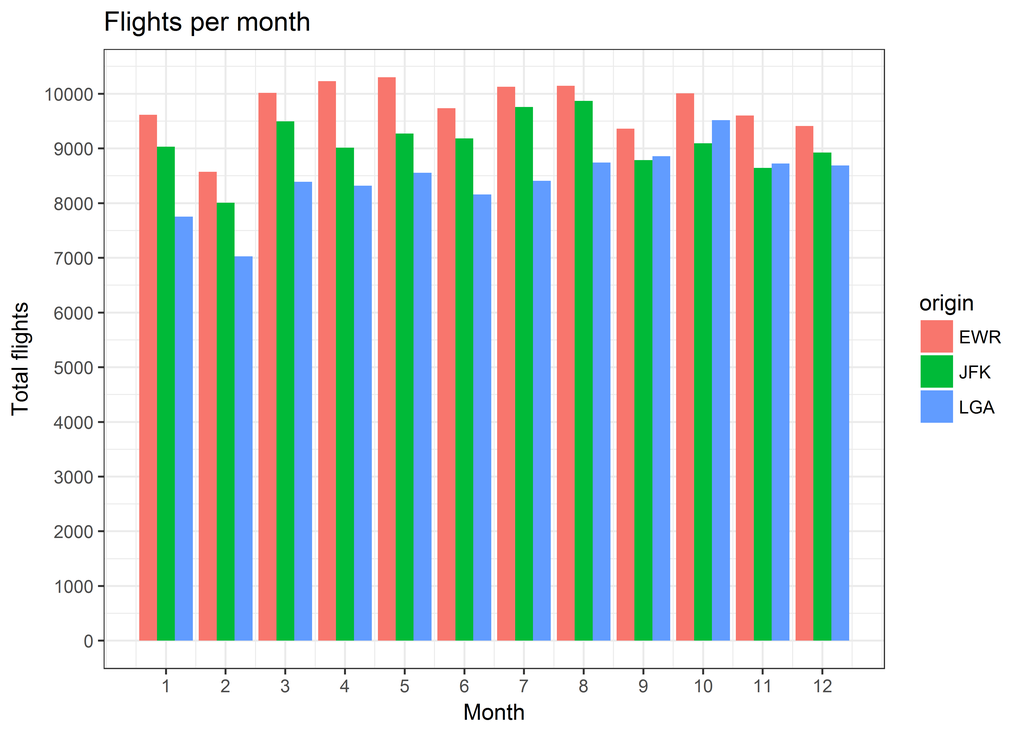

## 3.2 Exercise

What are the top-10 destinations and how many flights were made to these?

```
##
## --------------------
## dest     NoOfFlights
## ------ -------------
## ORD           17,283
##
## ATL           17,215
##
## LAX           16,174
##
## BOS           15,508
##
## MCO           14,082
##
## CLT           14,064
##
## SFO           13,331
##
## FLL           12,055
##
## MIA           11,728
##
## DCA            9,705
## --------------------
```

For these 10 destinations, make a barplot illustrating the number of flights from origin to top-10 destination.

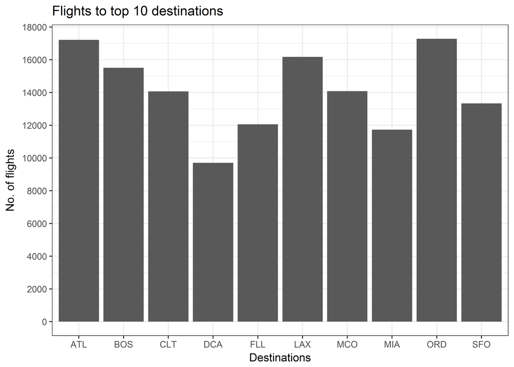

Now, order the bars (destinations) according to the total number of flights to these destinations.

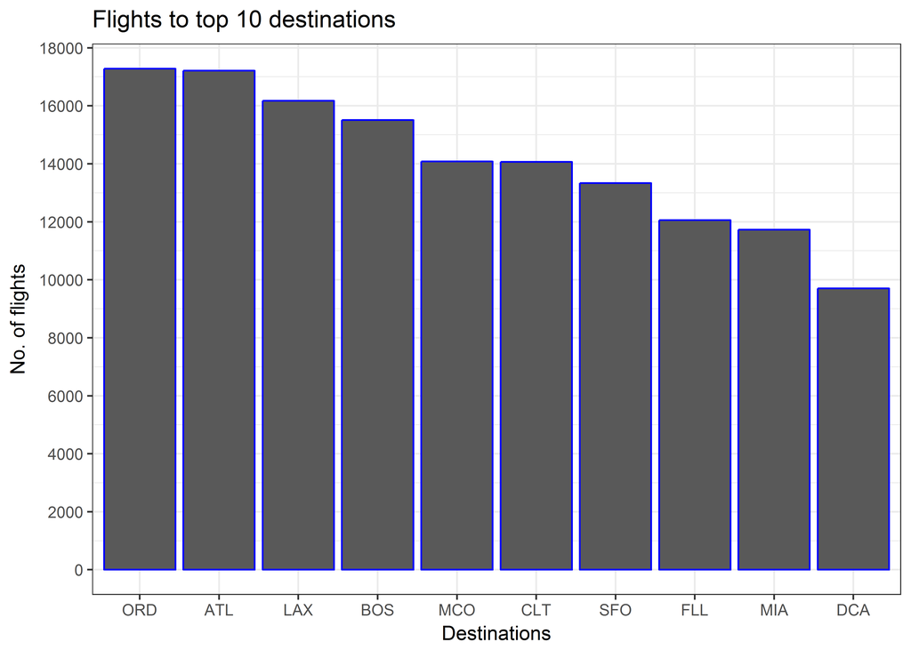

## Exercise

Is the mean air time from each of the three origins different? Further, are these differences statistically significant?

```r
#H0 : There is no difference between the population mean and the sample mean for the individual origins.
#H0 :  ??1 = ??2 = ??3

#Remove flights with NA air times
flightsWithAirTime <- flights %>% filter(!is.na(air_time)) %>% select(air_time, origin)


#Visualize the sample mean air time grouped by origin
flightsWithAirTime %>% group_by(origin) %>%  summarize(MeanAirTime =mean(air_time)) %>% pandoc.table(big.mark=",", justify = c('left', 'right'))
```

```
##
## ----------------------
## origin     MeanAirTime
## -------- -------------
## EWR              153.3
##
## JFK              178.3
##
## LGA              117.8
## ----------------------
```

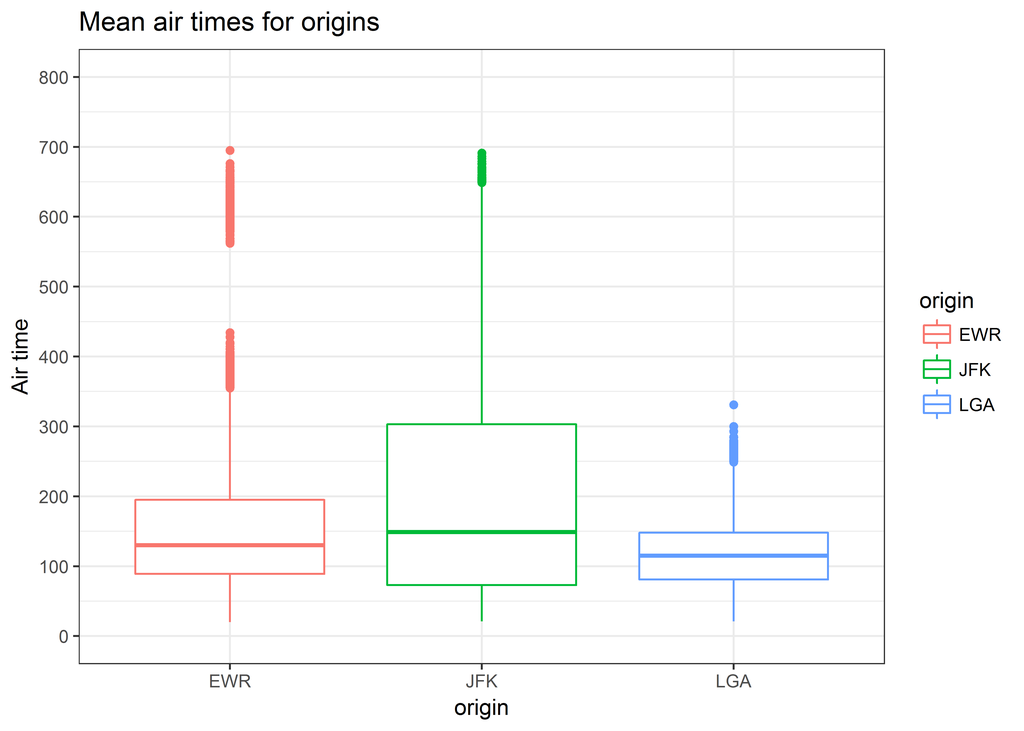

```r
#Visualizing by plotting
flightsWithAirTime %>% select(origin, air_time) %>% ggplot() + geom_boxplot(aes(origin, air_time, color=origin)) + scale_y_continuous(name="Air time", breaks=seq(0, 800, 100), limits=c(0,800)) + ggtitle("Mean air times for origins")
```

```r
#Conduct an ANOVA test at 5% significance level
flightsWithAirTime %>% aov(air_time ~ origin, data = .) %>% summary()
```

```
##                 Df    Sum Sq  Mean Sq F value Pr(>F)
## origin           2 1.935e+08 96741314   11817 <2e-16 ***
## Residuals   327343 2.680e+09     8186
## ---
## Signif. codes:  0 '***' 0.001 '**' 0.01 '*' 0.05 '.' 0.1 ' ' 1
```

```r
#Conclusion: P-Value
# In the results, the null hypothesis states that there is no difference between the population mean and the sample mean for the individual origins(??1 = ??2 = ??3 ). Since the p-value is less than the 5% significance level,we reject the hypothesis. At least one of them is different.
```

## 3.3 Exercise

How many weather observations are there for each origin?

```r
weather %>% na.omit() %>% group_by(origin) %>% summarize(Total=n()) %>% pandoc.table(big.mark=",", justify = c('left', 'right'))
```

```
##
## ----------------
## origin     Total
## -------- -------
## EWR        7,561
##
## JFK        7,836
##
## LGA        7,624
## ----------------
```

Convert temperature to degrees Celsius. This will be used in the reminder of this miniproject. (We do this for both `temp` and `dewp` using `mutate_at`)

```r
FahrenheitToDegrees <- function(temp)
{
  (temp-32)*5/9
}
weatherCleaned <- weather %>% filter(!is.na(temp), !is.na(dewp)) %>% mutate_at(vars(temp, dewp), funs(FahrenheitToDegrees))
```

Construct a graph displaying the temperature at `JFK`.

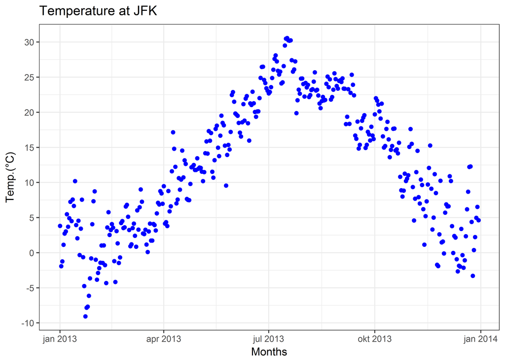

```r
jfkTemp <- weatherCleaned %>% filter(origin=='JFK') %>% mutate(date=make_date(year, month, day)) %>%  group_by(date) %>% summarize(deg=mean(temp))

plotJFKTemp <- function()
{
  ggplot(jfkTemp) + geom_point(aes(date, deg), color="blue") + labs(title="Temperature at JFK", x="Months", y="Temp.(°C)") + scale_y_continuous(breaks=seq(-20, 35, by=5))
}
plotJFKTemp()
```

Add a red line showing the mean temperature for each day.

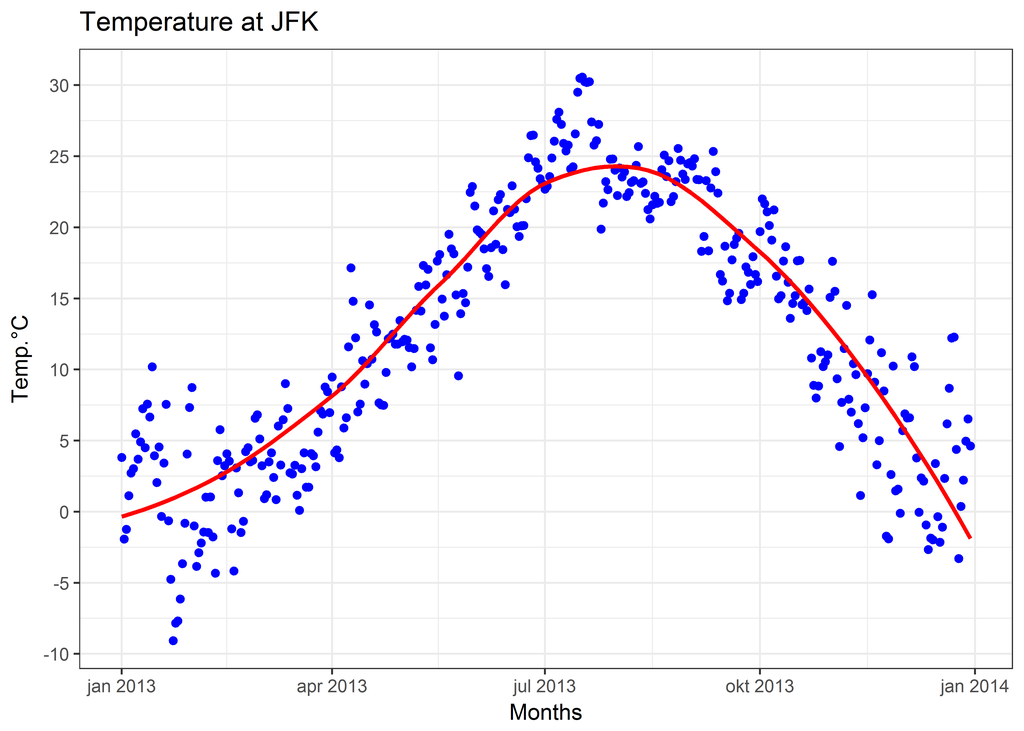

```r
ggplot(jfkTemp) + geom_point(aes(date, deg), color="blue") +
    geom_smooth(aes(date, deg, color=origin), color="red", se=F) + labs(title="Temperature at JFK", x="Months", y="Temp.°C") + scale_y_continuous(breaks=seq(-20, 50, by=5))
```

Now, visualize the daily mean temperature for each origin airport.

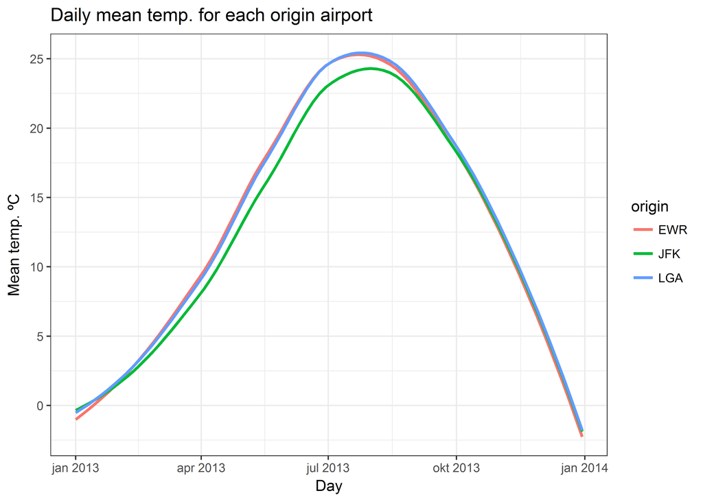

```r
#Get the daily mean temp
#Start by adding a date column of date type using lubridate's make_date function.
dailyMeanTempByOrigin <- weatherCleaned %>% mutate(date=make_date(year, month, day)) %>% group_by(origin, date) %>% summarize(MeanTemp = mean(temp))

#Plot each day's graph for each origin against the mean temperature
dailyMeanTempByOrigin %>% na.omit() %>% ggplot() + geom_smooth(aes(date, MeanTemp, color=origin), se=F) + labs(title = "Daily mean temp. for each origin airport", x="Day", y="Mean temp. ºC") + scale_y_continuous(breaks=seq(-20, 35, by=5))
```

## 3.4 Exercise

Investigate if arrival delay is associated with the flight distance (and also departure delay).

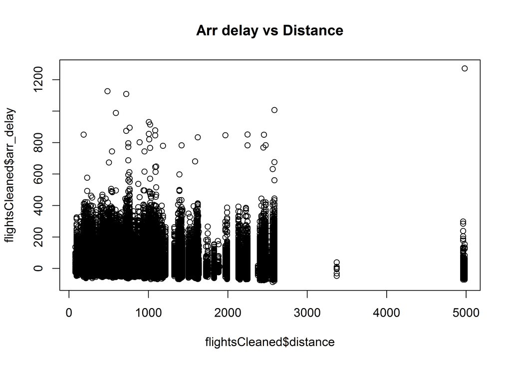

```r
#Clean the flights data set
flightsCleaned <- flights %>% filter(!is.na(arr_delay), !is.na(dep_delay), !is.na(distance))

#Visualize on a scatter plot
plot(flightsCleaned$distance, flightsCleaned$arr_delay, main="Arr delay vs Distance")
```

```r
cor.test(flightsCleaned$arr_delay, flightsCleaned$distance, method="pearson")
```

```
##
##  Pearson's product-moment correlation
##
## data:  flightsCleaned$arr_delay and flightsCleaned$distance
## t = -35.465, df = 327340, p-value < 2.2e-16
## alternative hypothesis: true correlation is not equal to 0
## 95 percent confidence interval:
##  -0.06527959 -0.05845448
## sample estimates:
##         cor
## -0.06186776
```

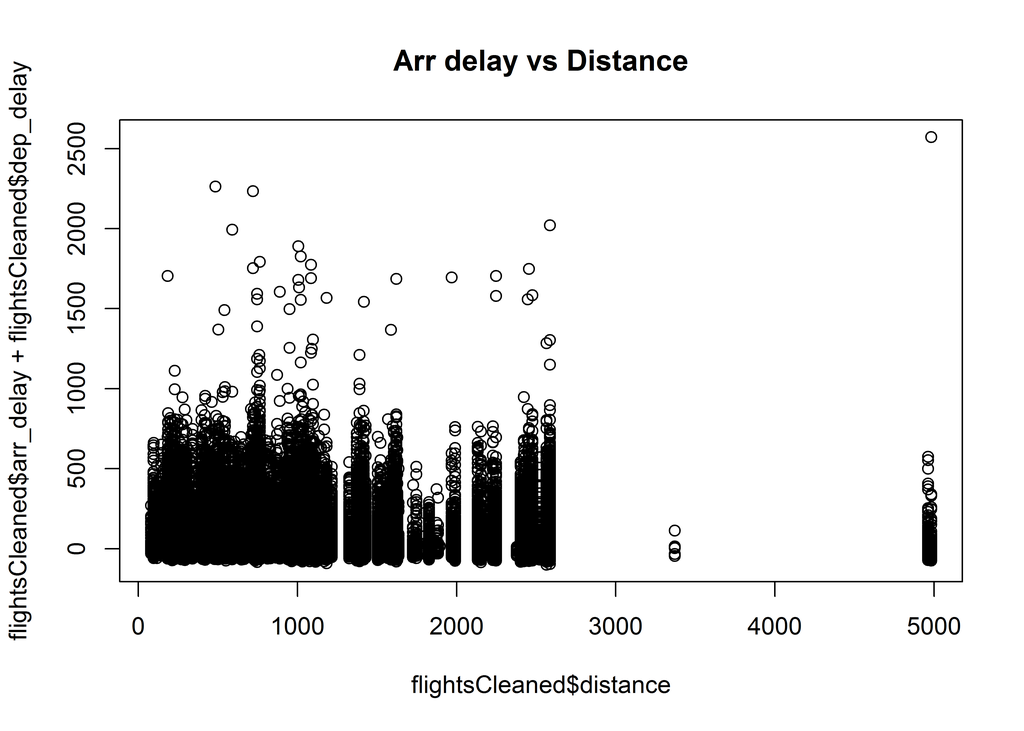

```r
#There is a fairly very weak negative relationship between arr_val and distance as attributed by the corr. coeffecient, r, -0.06186 and p value of <2.2e-16. This confirms the appearance of the scatter plot.

#Visualize on a scatter plot
plot(flightsCleaned$distance, flightsCleaned$arr_delay + flightsCleaned$dep_delay, main="Arr delay vs Distance")
```

```r
#Could also be visualized by the following code:
#library(ggpubr)
#ggscatter(flightsCleaned, x="distance", y="arr_delay", add="reg.line", conf.int=T, cor.coef=T, cor.method = "pearson")

cor.test(flightsCleaned$arr_delay + flightsCleaned$dep_delay, flightsCleaned$distance, method="pearson")
```

```
##
##  Pearson's product-moment correlation
##
## data:  flightsCleaned$arr_delay + flightsCleaned$dep_delay and flightsCleaned$distance
## t = -25.083, df = 327340, p-value < 2.2e-16
## alternative hypothesis: true correlation is not equal to 0
## 95 percent confidence interval:
##  -0.04721675 -0.04037856
## sample estimates:
##         cor
## -0.04379817
```

```r
#Again, the relationship between the delays and the distance is very weak though it exists, with a corre. coeffecient of -0.04.
```

## 3.5 Exercise

Investigate if departure delay is associated with weather conditions at the origin airport. This includes descriptives (mean departure delay), plotting, regression modelling, considering missing values etc.

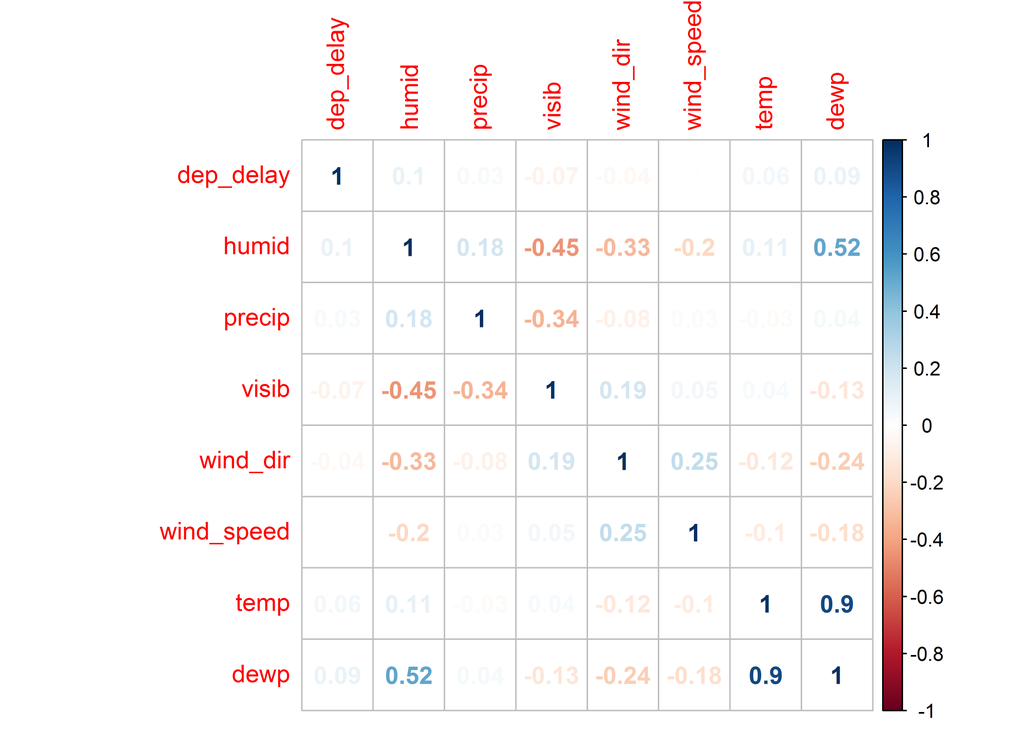

```r
#Prepare the data sets to be used.
weatherCleaned <- mutate_at(weather, vars(temp, dewp), funs(FahrenheitToDegrees)) %>% mutate(date=make_date(year, month, day))

flightDelay <- flights %>%  select(year:day, origin, hour, arr_delay, dep_delay, tailnum) %>% mutate(date=make_date(year, month, day))

flightsAndWeather <- inner_join(flightDelay, weatherCleaned, by = c("origin", "date")) %>% na.omit() %>% select(dep_delay, humid,precip, visib, wind_dir, wind_speed, temp, dewp)

#Visualize the relations
flightsAndWeather %>% cor() %>% corrplot(method="number")
```

```r
#There is a weak positive relationship between dep_delay and humid


set.seed(310)  #Used to ensure that the results are reproducible.
DelaySample <- caTools::sample.split(flightsAndWeather$dep_delay, SplitRatio = 0.7)
train <- subset(flightsAndWeather, DelaySample == T)

#Test set
test <- subset(flightsAndWeather, DelaySample == F)

#Model dep delay to the rest of the columns from the training data set
#We use the training set to produce the estimates of the coeffecients
model <- lm(dep_delay ~ ., data = train)
summary(model)
```

```
##
## Call:
## lm(formula = dep_delay ~ ., data = train)
##
## Residuals:
##     Min      1Q  Median      3Q     Max
## -110.90  -16.81  -11.87   -1.50 1290.55
##
## Coefficients:
##               Estimate Std. Error t value Pr(>|t|)
## (Intercept) 12.7930188  0.5866947  21.805   <2e-16 ***
## humid        0.0914842  0.0059205  15.452   <2e-16 ***
## precip      25.3541381  1.2706862  19.953   <2e-16 ***
## visib       -0.8313300  0.0143802 -57.811   <2e-16 ***
## wind_dir    -0.0020288  0.0001758 -11.539   <2e-16 ***
## wind_speed   0.0841741  0.0020360  41.342   <2e-16 ***
## temp        -0.0495424  0.0204272  -2.425   0.0153 *
## dewp         0.2655875  0.0219798  12.083   <2e-16 ***
## ---
## Signif. codes:  0 '***' 0.001 '**' 0.01 '*' 0.05 '.' 0.1 ' ' 1
##
## Residual standard error: 38.13 on 4832954 degrees of freedom
## Multiple R-squared:  0.01272,    Adjusted R-squared:  0.01272
## F-statistic:  8893 on 7 and 4832954 DF,  p-value: < 2.2e-16
```

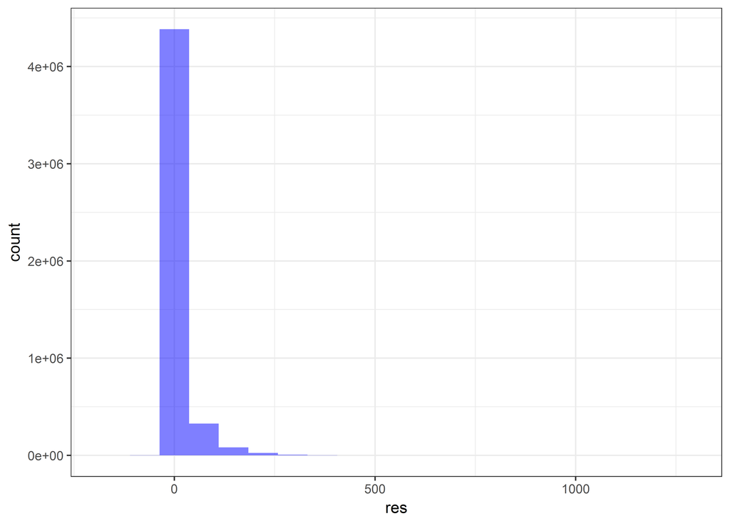

```r
#HAS BEEN CHANGED TO STATE THAT THERE IS A RELATIONSHIP
#There is a relationship between the weather conditions and the departure delay.

res <- residuals(model) %>% as.data.frame()

res %>% ggplot(aes(res)) +  geom_histogram(fill='blue',alpha=0.5, bins = 20)
```

```r
#Prediction computation

delayPredict <- predict(model, test)
predictRes  <- cbind(delayPredict, test$dep_delay) %>% as.data.frame()
colnames(predictRes) <- c("predict", "actual")

#Uncomment for output
#predictRes
```